# Cricket Data EDA

Youssef Othman

2025-10-05

In this Markdown we will look at data from Men’s ODI matches from 2015 onwards.

#### Required Libraries:

```r
required_packages <- c(
  "readr",
  "dplyr",
  "ggplot2"
)

# Install any missing packages
for (pkg in required_packages) {
  if (!require(pkg, character.only = TRUE)) {
    install.packages(pkg, dependencies = TRUE)
    library(pkg, character.only = TRUE)
  } else {
    library(pkg, character.only = TRUE)
  }
}
```

#### Load Data and check missing values :

We load the processed Mens ODI ball by ball data from 2015 onwards:

```r
# Relative path from the project root (Make sure to set your working directory)
data_file <- "data/odi_bbb_recent.csv"

# Read the CSV into a dataframe
odi_bbb_recent <- read_csv(data_file,show_col_types = FALSE)
# Check columns of the data
glimpse(odi_bbb_recent)
```

```
## Rows: 620,647
## Columns: 29
## $ match_id               <dbl> 749781, 749781, 749781, 749781, 749781, 749781,…
## $ season                 <chr> "2014/15", "2014/15", "2014/15", "2014/15", "20…
## $ start_date             <date> 2015-01-11, 2015-01-11, 2015-01-11, 2015-01-11…
## $ venue                  <chr> "Hagley Oval", "Hagley Oval", "Hagley Oval", "H…
## $ innings                <dbl> 1, 1, 1, 1, 1, 1, 1, 1, 1, 1, 1, 1, 1, 1, 1, 1,…
## $ ball                   <dbl> 0.1, 0.2, 0.3, 0.4, 0.5, 0.6, 0.7, 0.8, 1.1, 1.…
## $ batting_team           <chr> "Sri Lanka", "Sri Lanka", "Sri Lanka", "Sri Lan…
## $ bowling_team           <chr> "New Zealand", "New Zealand", "New Zealand", "N…
## $ striker                <chr> "FDM Karunaratne", "TM Dilshan", "TM Dilshan", …
## $ non_striker            <chr> "TM Dilshan", "FDM Karunaratne", "FDM Karunarat…
## $ bowler                 <chr> "TA Boult", "TA Boult", "TA Boult", "TA Boult",…
## $ runs_off_bat           <dbl> 1, 0, 0, 0, 0, 0, 0, 0, 1, 0, 0, 0, 0, 0, 2, 0,…
## $ extras                 <dbl> 0, 0, 0, 1, 1, 0, 0, 0, 0, 0, 0, 0, 0, 0, 0, 0,…
```

[output cut: 16 more lines]

We observe the dimensions of the data and the number of missing values:

```r
odi <- odi_bbb_recent

# Number of rows and columns
dim(odi)
```

```
## [1] 620647     29
```

```r
# Count unique matches
n_matches <- odi %>% summarise(n_matches = n_distinct(match_id))
n_matches
```

```
## # A tibble: 1 × 1
##   n_matches
##       <int>
## 1      1173
```

```r
# Check missing values by column
colSums(is.na(odi))
```

```
##               match_id                 season             start_date
##                      0                      0                      0
##                  venue                innings                   ball
##                      0                      0                      0
##           batting_team           bowling_team                striker
##                      0                      0                      0
##            non_striker                 bowler           runs_off_bat
##                      0                      0                      0
##                 extras                  wides                noballs
##                      0                 606354                 619247
##                   byes                legbyes                penalty
##                 619645                 615281                 620647
##            wicket_type       player_dismissed      other_wicket_type
##                 603430                 603430                 620647
## other_player_dismissed                 winner            toss_winner
##                 620647                  16505                      0
##          toss_decision                  team1                  team2
##                      0                      0                      0
##          bowling_style          batting_style
##                   3323                   1522
```

## Initial Exploration:

We check how consistent our data is across the 10 seasons of cricket we are considering .

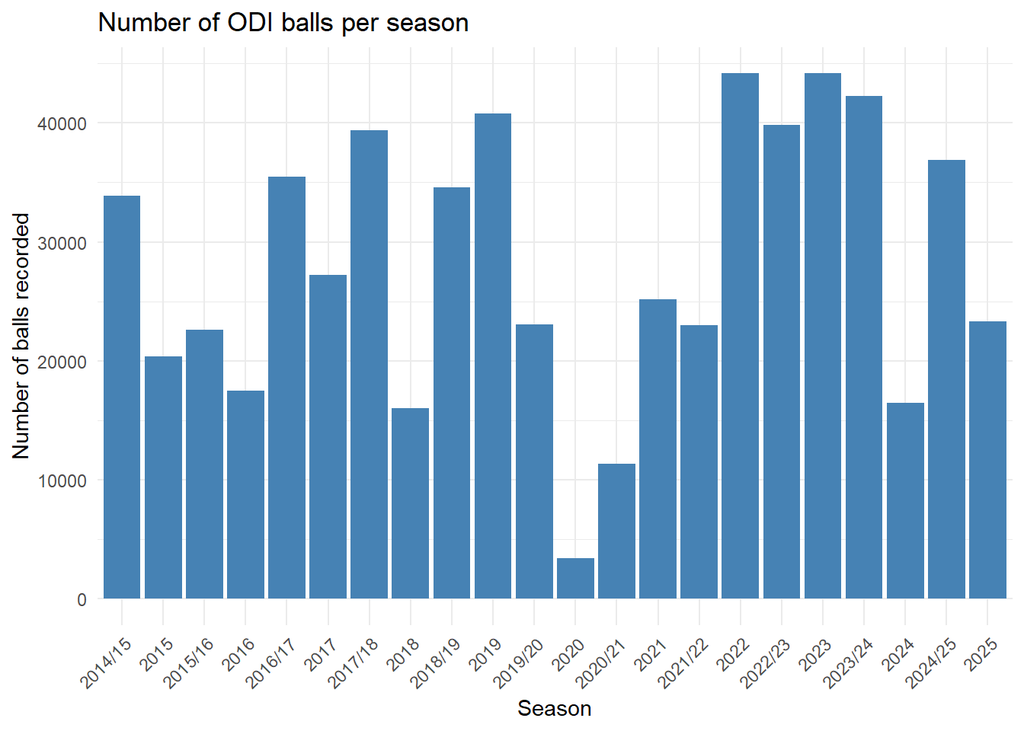

```r
odi %>%
  count(season) %>%
  ggplot(aes(x = season, y = n)) +
  geom_col(fill = "steelblue") +
  labs(
    title = "Number of ODI balls per season",
    x = "Season",
    y = "Number of balls recorded"
  ) +
  theme_minimal() +
  theme(axis.text.x = element_text(angle = 45, hjust = 1))
```

Here the low number of balls in 2020 and 2020/21 being due to the impact of the COVID-19 pandemic.

We explore the Top 10 ODI Teams by Runs to see if there is a stark difference between competitors.

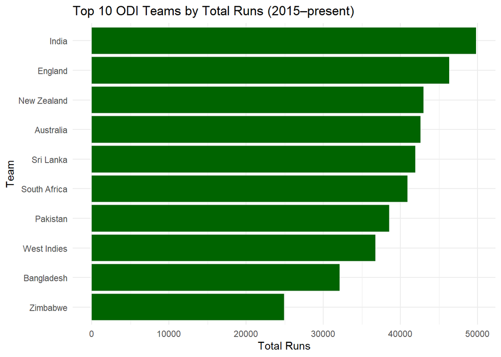

```r
odi %>%
  group_by(batting_team) %>%
  summarise(total_runs = sum(runs_off_bat + coalesce(extras, 0), na.rm = TRUE)) %>%
  arrange(desc(total_runs)) %>%
  slice_head(n = 10) %>%
  ggplot(aes(x = reorder(batting_team, total_runs), y = total_runs)) +
  geom_col(fill = "darkgreen") +
  coord_flip() +
  labs(
    title = "Top 10 ODI Teams by Total Runs (2015–present)",
    x = "Team",
    y = "Total Runs"
  ) +
  theme_minimal()
```

It seems that the top teams are not dominating the game and there is a fair amount of competition in between teams.

We check for the competition between the best batters:

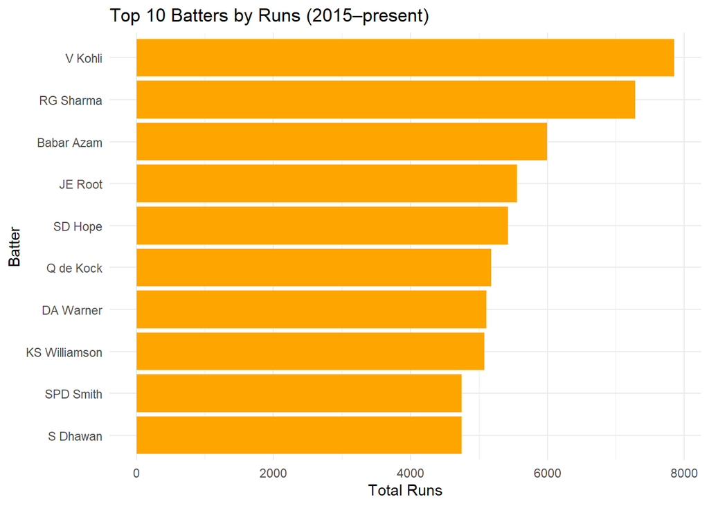

```r
odi %>%
  group_by(striker) %>%
  summarise(total_runs = sum(runs_off_bat, na.rm = TRUE)) %>%
  arrange(desc(total_runs)) %>%
  slice_head(n = 10) %>%
  ggplot(aes(x = reorder(striker, total_runs), y = total_runs)) +
  geom_col(fill = "orange") +
  coord_flip() +
  labs(
    title = "Top 10 Batters by Runs (2015–present)",
    x = "Batter",
    y = "Total Runs"
  ) +
  theme_minimal()
```

Here the top 2 batters seem to be dominating in total runs comparitively to the other 8 batters but this might be due to factors such as injury resistance, number of games played etc. . Would be interesting to investigate this plot further and look at the difference in the top 2 players compared to the others.

## Bowling Style vs. Number of runs:

We look at if bowling style affects the number of runs.

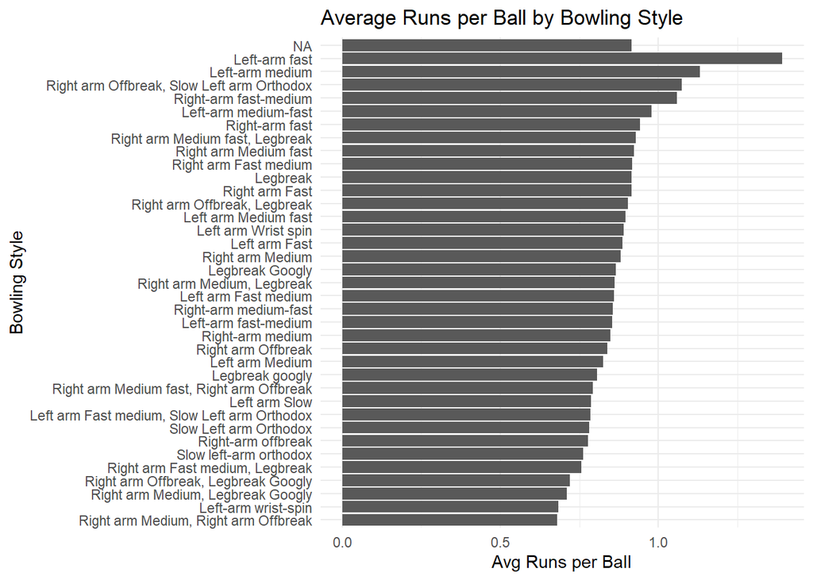

```r
# Average runs conceded by bowling style
odi %>%
  group_by(bowling_style) %>%
  summarise(avg_runs_per_ball = mean(runs_off_bat + coalesce(extras, 0), na.rm = TRUE)) %>%
  arrange(desc(avg_runs_per_ball)) %>%
  ggplot(aes(x = reorder(bowling_style, avg_runs_per_ball), y = avg_runs_per_ball)) +
  geom_col() +
  coord_flip() +
  labs(
    title = "Average Runs per Ball by Bowling Style",
    x = "Bowling Style",
    y = "Avg Runs per Ball"
  ) +
  theme_minimal()
```

Looking at this plot we can see a clear outlier with left-arm fast being the worst bowling style as it concedes the most runs.

We now look to improve this plot to check if this outlier is caused by insufficient data and we check it’s relation to the mean of the data. We colour code the above average bowling economy in red and the below average in blue.

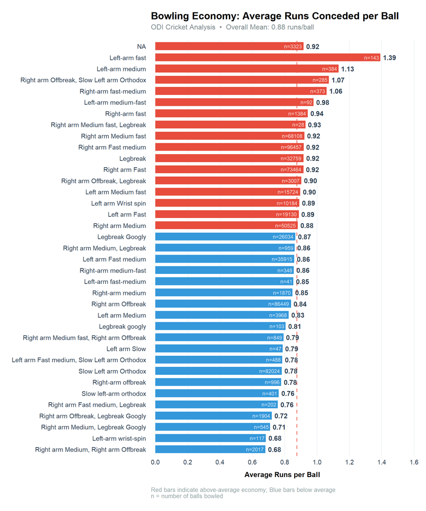

```r
# Calculate statistics for bowling styles
bowling_stats <- odi %>%
  group_by(bowling_style) %>%
  summarise(
    avg_runs_per_ball = mean(runs_off_bat + coalesce(extras, 0), na.rm = TRUE),
    balls_bowled = n(),
    .groups = 'drop'
  ) %>%
  arrange(desc(avg_runs_per_ball))

# Calculate overall mean
overall_mean <- mean(bowling_stats$avg_runs_per_ball)
# Calculate dynamic height based on number of categories
n_styles <- nrow(bowling_stats)
plot_height <- max(8, n_styles * 0.4)  # At least 8 inches, or 0.4 inches per style

# Create enhanced plot
p <- ggplot(bowling_stats, aes(x = reorder(bowling_style, avg_runs_per_ball),
                          y = avg_runs_per_ball)) +

  # Add horizontal line for overall mean
  geom_hline(yintercept = overall_mean,
             linetype = "dashed",
             color = "#E74C3C",
             linewidth = 0.8,
             alpha = 0.7) +

  # Bars with conditional coloring (above/below mean)
  geom_col(aes(fill = avg_runs_per_ball > overall_mean),
           width = 0.7,
           show.legend = FALSE) +

  # Add value labels on bars
  geom_text(aes(label = sprintf("%.2f", avg_runs_per_ball)),
            hjust = -0.2,
            size = 4,
            color = "#2C3E50",
            fontface = "bold") +

  # Add sample size labels (balls bowled)
  geom_text(aes(label = paste0("n=", balls_bowled)),
            hjust = 1.1,
            size = 3.2,
            color = "white",
            alpha = 0.8) +

  # Color scheme
  scale_fill_manual(values = c("TRUE" = "#E74C3C", "FALSE" = "#3498DB")) +

  # Flip coordinates
  coord_flip(clip = "off") +

  # Expand y-axis to show labels
  scale_y_continuous(expand = expansion(mult = c(0.02, 0.15)),
                     breaks = seq(0, 2, 0.2)) +

  # Labels and title
  labs(
    title = "Bowling Economy: Average Runs Conceded per Ball",
    subtitle = paste0("ODI Cricket Analysis  •  Overall Mean: ",
                     sprintf("%.2f", overall_mean), " runs/ball"),
    x = NULL,
    y = "Average Runs per Ball",
    caption = "Red bars indicate above-average economy; Blue bars below average\nn = number of balls bowled"
  ) +

  # Theme customization
  theme_minimal(base_size = 13) +
  theme(
    plot.title = element_text(face = "bold", size = 17, margin = margin(b = 5)),
    plot.subtitle = element_text(size = 12, color = "#7F8C8D", margin = margin(b = 15)),
    plot.caption = element_text(size = 10, color = "#95A5A6", hjust = 0,
                               margin = margin(t = 15)),
    axis.text.y = element_text(size = 11, color = "#2C3E50", margin = margin(r = 5)),
    axis.text.x = element_text(size = 11, color = "#2C3E50"),
    axis.title.x = element_text(face = "bold", size = 12, margin = margin(t = 10)),
    panel.grid.major.y = element_blank(),
    panel.grid.minor = element_blank(),
    panel.grid.major.x = element_line(color = "#ECF0F1", linewidth = 0.5),
    plot.margin = margin(20, 20, 20, 20)
  )

# Print the plot with appropriate dimensions for HTML
print(p)
```

Looking at this plot we notice that there is a wide range of number of balls bowled per playing style and this plot does not currently factor for that variance.